# Risk Factor Analysis

## Outcome Variable

**Outcome Variable:** swasted

## Predictor Variables

**Intervention Variable:** feducyrs

**Adjustment Set:**

- arm
- W_mage
- meducyrs
- W_mhtcm
- W_gagebrth
- W_birthwt
- W_birthlen
- single
- delta_W_mage
- delta_meducyrs
- delta_W_mhtcm
- delta_W_gagebrth
- delta_W_birthwt
- delta_W_birthlen
- delta_single

## Stratifying Variables

The analysis was stratified on these variable(s):

- agecat
- studyid
- country

## Data Summary

| agecat | studyid | country | feducyrs | swasted | n_cell | n |
| --- | --- | --- | --- | --- | --- | --- |
| Birth | ki0047075b-MAL-ED | BANGLADESH | High | 0 | 47 | 134 |
| Birth | ki0047075b-MAL-ED | BANGLADESH | High | 1 | 2 | 134 |
| Birth | ki0047075b-MAL-ED | BANGLADESH | Low | 0 | 32 | 134 |
| Birth | ki0047075b-MAL-ED | BANGLADESH | Low | 1 | 3 | 134 |
| Birth | ki0047075b-MAL-ED | BANGLADESH | Medium | 0 | 49 | 134 |
| Birth | ki0047075b-MAL-ED | BANGLADESH | Medium | 1 | 1 | 134 |
| Birth | ki0047075b-MAL-ED | INDIA | High | 0 | 38 | 121 |
| Birth | ki0047075b-MAL-ED | INDIA | High | 1 | 0 | 121 |
| Birth | ki0047075b-MAL-ED | INDIA | Low | 0 | 46 | 121 |
| Birth | ki0047075b-MAL-ED | INDIA | Low | 1 | 2 | 121 |
| Birth | ki0047075b-MAL-ED | INDIA | Medium | 0 | 35 | 121 |
| Birth | ki0047075b-MAL-ED | INDIA | Medium | 1 | 0 | 121 |
| Birth | ki0047075b-MAL-ED | NEPAL | High | 0 | 27 | 64 |
| Birth | ki0047075b-MAL-ED | NEPAL | High | 1 | 0 | 64 |
| Birth | ki0047075b-MAL-ED | NEPAL | Low | 0 | 18 | 64 |
| Birth | ki0047075b-MAL-ED | NEPAL | Low | 1 | 0 | 64 |
| Birth | ki0047075b-MAL-ED | NEPAL | Medium | 0 | 19 | 64 |
| Birth | ki0047075b-MAL-ED | NEPAL | Medium | 1 | 0 | 64 |
| Birth | ki0047075b-MAL-ED | PERU | High | 0 | 112 | 230 |
| Birth | ki0047075b-MAL-ED | PERU | High | 1 | 0 | 230 |
| Birth | ki0047075b-MAL-ED | PERU | Low | 0 | 63 | 230 |
| Birth | ki0047075b-MAL-ED | PERU | Low | 1 | 0 | 230 |
| Birth | ki0047075b-MAL-ED | PERU | Medium | 0 | 55 | 230 |
| Birth | ki0047075b-MAL-ED | PERU | Medium | 1 | 0 | 230 |
| Birth | ki0047075b-MAL-ED | SOUTH AFRICA | High | 0 | 35 | 91 |
| Birth | ki0047075b-MAL-ED | SOUTH AFRICA | High | 1 | 0 | 91 |
| Birth | ki0047075b-MAL-ED | SOUTH AFRICA | Low | 0 | 30 | 91 |
| Birth | ki0047075b-MAL-ED | SOUTH AFRICA | Low | 1 | 0 | 91 |
| Birth | ki0047075b-MAL-ED | SOUTH AFRICA | Medium | 0 | 26 | 91 |
| Birth | ki0047075b-MAL-ED | SOUTH AFRICA | Medium | 1 | 0 | 91 |

[output cut: 288 more lines]

The following strata were considered:

- agecat: 24 months, studyid: ki0047075b-MAL-ED, country: BANGLADESH
- agecat: 24 months, studyid: ki0047075b-MAL-ED, country: INDIA
- agecat: 24 months, studyid: ki0047075b-MAL-ED, country: NEPAL
- agecat: 24 months, studyid: ki0047075b-MAL-ED, country: PERU
- agecat: 24 months, studyid: ki0047075b-MAL-ED, country: SOUTH AFRICA
- agecat: 24 months, studyid: ki0047075b-MAL-ED, country: TANZANIA, UNITED REPUBLIC OF
- agecat: 24 months, studyid: ki1017093b-PROVIDE, country: BANGLADESH
- agecat: 24 months, studyid: ki1017093c-NIH-Crypto, country: BANGLADESH
- agecat: 24 months, studyid: ki1066203-TanzaniaChild2, country: TANZANIA, UNITED REPUBLIC OF
- agecat: 24 months, studyid: ki1113344-GMS-Nepal, country: NEPAL
- agecat: 24 months, studyid: ki1119695-PROBIT, country: BELARUS
- agecat: 24 months, studyid: ki1126311-ZVITAMBO, country: ZIMBABWE
- agecat: 24 months, studyid: ki1135781-COHORTS, country: GUATEMALA
- agecat: 24 months, studyid: ki1135781-COHORTS, country: INDIA
- agecat: 24 months, studyid: ki1135781-COHORTS, country: PHILIPPINES
- agecat: 24 months, studyid: ki1148112-LCNI-5, country: MALAWI
- agecat: 24 months, studyid: kiGH5241-JiVitA-3, country: BANGLADESH
- agecat: 24 months, studyid: kiGH5241-JiVitA-4, country: BANGLADESH
- agecat: 6 months, studyid: ki0047075b-MAL-ED, country: BANGLADESH
- agecat: 6 months, studyid: ki0047075b-MAL-ED, country: INDIA
- agecat: 6 months, studyid: ki0047075b-MAL-ED, country: NEPAL
- agecat: 6 months, studyid: ki0047075b-MAL-ED, country: PERU
- agecat: 6 months, studyid: ki0047075b-MAL-ED, country: SOUTH AFRICA
- agecat: 6 months, studyid: ki0047075b-MAL-ED, country: TANZANIA, UNITED REPUBLIC OF
- agecat: 6 months, studyid: ki1000304b-SAS-CompFeed, country: INDIA
- agecat: 6 months, studyid: ki1000304b-SAS-FoodSuppl, country: INDIA
- agecat: 6 months, studyid: ki1017093b-PROVIDE, country: BANGLADESH
- agecat: 6 months, studyid: ki1017093c-NIH-Crypto, country: BANGLADESH
- agecat: 6 months, studyid: ki1066203-TanzaniaChild2, country: TANZANIA, UNITED REPUBLIC OF
- agecat: 6 months, studyid: ki1113344-GMS-Nepal, country: NEPAL
- agecat: 6 months, studyid: ki1119695-PROBIT, country: BELARUS
- agecat: 6 months, studyid: ki1126311-ZVITAMBO, country: ZIMBABWE
- agecat: 6 months, studyid: ki1135781-COHORTS, country: GUATEMALA
- agecat: 6 months, studyid: ki1135781-COHORTS, country: INDIA
- agecat: 6 months, studyid: ki1135781-COHORTS, country: PHILIPPINES
- agecat: 6 months, studyid: ki1148112-LCNI-5, country: MALAWI
- agecat: 6 months, studyid: kiGH5241-JiVitA-3, country: BANGLADESH
- agecat: 6 months, studyid: kiGH5241-JiVitA-4, country: BANGLADESH
- agecat: Birth, studyid: ki0047075b-MAL-ED, country: BANGLADESH
- agecat: Birth, studyid: ki0047075b-MAL-ED, country: INDIA
- agecat: Birth, studyid: ki0047075b-MAL-ED, country: NEPAL
- agecat: Birth, studyid: ki0047075b-MAL-ED, country: PERU
- agecat: Birth, studyid: ki0047075b-MAL-ED, country: SOUTH AFRICA
- agecat: Birth, studyid: ki0047075b-MAL-ED, country: TANZANIA, UNITED REPUBLIC OF
- agecat: Birth, studyid: ki1000304b-SAS-CompFeed, country: INDIA
- agecat: Birth, studyid: ki1017093c-NIH-Crypto, country: BANGLADESH
- agecat: Birth, studyid: ki1119695-PROBIT, country: BELARUS
- agecat: Birth, studyid: ki1126311-ZVITAMBO, country: ZIMBABWE
- agecat: Birth, studyid: ki1135781-COHORTS, country: GUATEMALA
- agecat: Birth, studyid: ki1135781-COHORTS, country: INDIA
- agecat: Birth, studyid: ki1135781-COHORTS, country: PHILIPPINES
- agecat: Birth, studyid: kiGH5241-JiVitA-3, country: BANGLADESH
- agecat: Birth, studyid: kiGH5241-JiVitA-4, country: BANGLADESH

### Dropped Strata

Some strata were dropped due to rare outcomes:

- agecat: Birth, studyid: ki0047075b-MAL-ED, country: BANGLADESH
- agecat: Birth, studyid: ki0047075b-MAL-ED, country: INDIA
- agecat: Birth, studyid: ki0047075b-MAL-ED, country: NEPAL
- agecat: Birth, studyid: ki0047075b-MAL-ED, country: PERU
- agecat: Birth, studyid: ki0047075b-MAL-ED, country: SOUTH AFRICA
- agecat: Birth, studyid: ki0047075b-MAL-ED, country: TANZANIA, UNITED REPUBLIC OF
- agecat: Birth, studyid: ki1000304b-SAS-CompFeed, country: INDIA
- agecat: Birth, studyid: ki1017093c-NIH-Crypto, country: BANGLADESH
- agecat: Birth, studyid: kiGH5241-JiVitA-4, country: BANGLADESH
- agecat: 6 months, studyid: ki0047075b-MAL-ED, country: BANGLADESH
- agecat: 6 months, studyid: ki0047075b-MAL-ED, country: INDIA
- agecat: 6 months, studyid: ki0047075b-MAL-ED, country: NEPAL
- agecat: 6 months, studyid: ki0047075b-MAL-ED, country: PERU
- agecat: 6 months, studyid: ki0047075b-MAL-ED, country: SOUTH AFRICA
- agecat: 6 months, studyid: ki0047075b-MAL-ED, country: TANZANIA, UNITED REPUBLIC OF
- agecat: 6 months, studyid: ki1017093b-PROVIDE, country: BANGLADESH
- agecat: 6 months, studyid: ki1017093c-NIH-Crypto, country: BANGLADESH
- agecat: 6 months, studyid: ki1066203-TanzaniaChild2, country: TANZANIA, UNITED REPUBLIC OF
- agecat: 6 months, studyid: ki1113344-GMS-Nepal, country: NEPAL
- agecat: 6 months, studyid: ki1119695-PROBIT, country: BELARUS
- agecat: 6 months, studyid: ki1135781-COHORTS, country: GUATEMALA
- agecat: 6 months, studyid: ki1148112-LCNI-5, country: MALAWI
- agecat: 6 months, studyid: kiGH5241-JiVitA-4, country: BANGLADESH
- agecat: 24 months, studyid: ki0047075b-MAL-ED, country: BANGLADESH
- agecat: 24 months, studyid: ki0047075b-MAL-ED, country: INDIA
- agecat: 24 months, studyid: ki0047075b-MAL-ED, country: NEPAL
- agecat: 24 months, studyid: ki0047075b-MAL-ED, country: PERU
- agecat: 24 months, studyid: ki0047075b-MAL-ED, country: SOUTH AFRICA
- agecat: 24 months, studyid: ki0047075b-MAL-ED, country: TANZANIA, UNITED REPUBLIC OF
- agecat: 24 months, studyid: ki1017093b-PROVIDE, country: BANGLADESH
- agecat: 24 months, studyid: ki1017093c-NIH-Crypto, country: BANGLADESH
- agecat: 24 months, studyid: ki1066203-TanzaniaChild2, country: TANZANIA, UNITED REPUBLIC OF
- agecat: 24 months, studyid: ki1113344-GMS-Nepal, country: NEPAL
- agecat: 24 months, studyid: ki1119695-PROBIT, country: BELARUS
- agecat: 24 months, studyid: ki1126311-ZVITAMBO, country: ZIMBABWE
- agecat: 24 months, studyid: ki1135781-COHORTS, country: GUATEMALA
- agecat: 24 months, studyid: ki1135781-COHORTS, country: INDIA
- agecat: 24 months, studyid: ki1135781-COHORTS, country: PHILIPPINES
- agecat: 24 months, studyid: ki1148112-LCNI-5, country: MALAWI

## Methods Detail

We’re interested in the causal parameters $E[Y_a]$ for all values of $a \in \mathcal{A}$. These parameters represent the mean outcome if, possibly contrary to fact, we intervened to set all units to have $A=a$. Under the randomization and positivity assumptions, these are identified by the statistical parameters $\psi_a=E_W[E_{Y|A,W}(Y|A=a,W)]$. In addition, we’re interested in the mean of $Y$, $E[Y]$ under no intervention (the observed mean). We will estimate these parameters by using SuperLearner to fit the relevant likelihood factors – $E_{Y|A,W}(Y|A=a,W)$ and $p(A=a|W)$, and then updating our likelihood fit using a joint TMLE.

For unadjusted analyses ($W=\{\}$), initial likelihoods were estimated using Lrnr_glm to estimate the simple $E(Y|A)$ and Lrnr_mean to estimate $p(A)$. For adjusted analyses, a small library containing Lrnr_glmnet, Lrnr_xgboost, and Lrnr_mean was used.

Having estimated these parameters, we will then use the delta method to estimate relative risks and attributable risks relative to a prespecified baseline level of $A$.

# Results Detail

## Results Plots

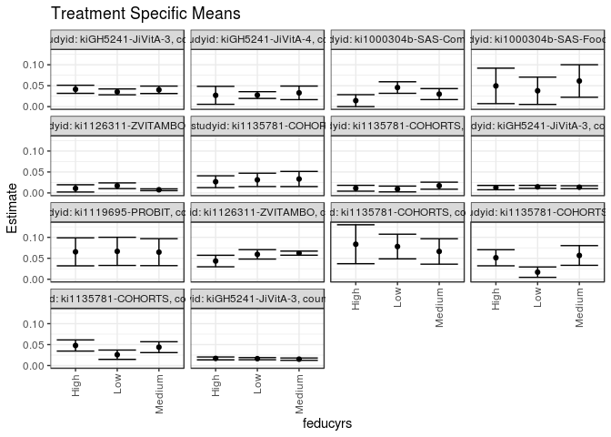

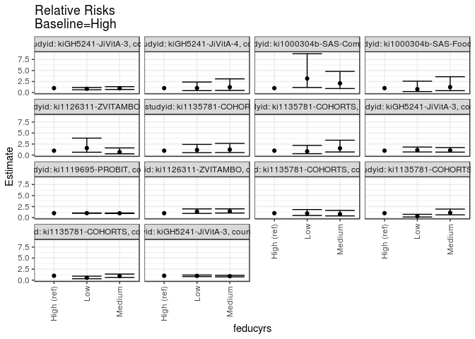

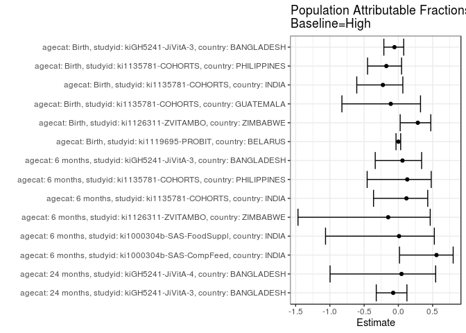

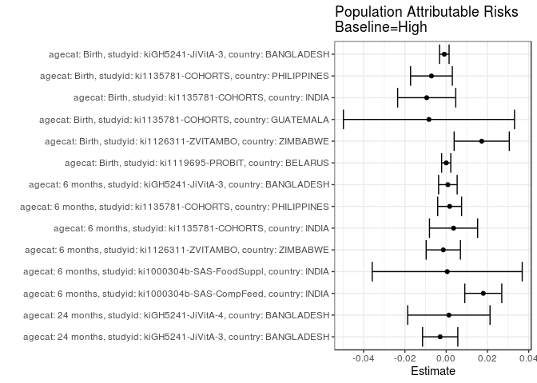

## Results Table

### Parameter: TSM

| agecat | studyid | country | intervention_level | baseline_level | estimate | ci_lower | ci_upper |
| --- | --- | --- | --- | --- | --- | --- | --- |
| Birth | ki1119695-PROBIT | BELARUS | High | NA | 0.0654217 | 0.0319972 | 0.0988461 |
| Birth | ki1119695-PROBIT | BELARUS | Low | NA | 0.0665674 | 0.0329556 | 0.1001793 |
| Birth | ki1119695-PROBIT | BELARUS | Medium | NA | 0.0646319 | 0.0324721 | 0.0967917 |
| Birth | ki1126311-ZVITAMBO | ZIMBABWE | High | NA | 0.0434666 | 0.0297188 | 0.0572144 |
| Birth | ki1126311-ZVITAMBO | ZIMBABWE | Low | NA | 0.0593882 | 0.0481258 | 0.0706505 |
| Birth | ki1126311-ZVITAMBO | ZIMBABWE | Medium | NA | 0.0622931 | 0.0574031 | 0.0671831 |
| Birth | ki1135781-COHORTS | GUATEMALA | High | NA | 0.0835689 | 0.0370607 | 0.1300771 |
| Birth | ki1135781-COHORTS | GUATEMALA | Low | NA | 0.0780926 | 0.0486512 | 0.1075339 |
| Birth | ki1135781-COHORTS | GUATEMALA | Medium | NA | 0.0663260 | 0.0359379 | 0.0967142 |
| Birth | ki1135781-COHORTS | INDIA | High | NA | 0.0512821 | 0.0320749 | 0.0704892 |
| Birth | ki1135781-COHORTS | INDIA | Low | NA | 0.0169082 | 0.0044842 | 0.0293322 |
| Birth | ki1135781-COHORTS | INDIA | Medium | NA | 0.0567568 | 0.0331717 | 0.0803418 |
| Birth | ki1135781-COHORTS | PHILIPPINES | High | NA | 0.0478387 | 0.0344827 | 0.0611947 |
| Birth | ki1135781-COHORTS | PHILIPPINES | Low | NA | 0.0258478 | 0.0147110 | 0.0369845 |
| Birth | ki1135781-COHORTS | PHILIPPINES | Medium | NA | 0.0438541 | 0.0308677 | 0.0568405 |
| Birth | kiGH5241-JiVitA-3 | BANGLADESH | High | NA | 0.0169832 | 0.0135602 | 0.0204062 |
| Birth | kiGH5241-JiVitA-3 | BANGLADESH | Low | NA | 0.0164058 | 0.0138091 | 0.0190024 |
| Birth | kiGH5241-JiVitA-3 | BANGLADESH | Medium | NA | 0.0152169 | 0.0125004 | 0.0179335 |
| 6 months | ki1000304b-SAS-CompFeed | INDIA | High | NA | 0.0143266 | 0.0000589 | 0.0285944 |
| 6 months | ki1000304b-SAS-CompFeed | INDIA | Low | NA | 0.0456204 | 0.0318281 | 0.0594127 |
| 6 months | ki1000304b-SAS-CompFeed | INDIA | Medium | NA | 0.0299539 | 0.0168697 | 0.0430382 |
| 6 months | ki1000304b-SAS-FoodSuppl | INDIA | High | NA | 0.0495050 | 0.0071447 | 0.0918652 |
| 6 months | ki1000304b-SAS-FoodSuppl | INDIA | Low | NA | 0.0378788 | 0.0052691 | 0.0704884 |
| 6 months | ki1000304b-SAS-FoodSuppl | INDIA | Medium | NA | 0.0612245 | 0.0224179 | 0.1000310 |
| 6 months | ki1126311-ZVITAMBO | ZIMBABWE | High | NA | 0.0108696 | 0.0022191 | 0.0195200 |
| 6 months | ki1126311-ZVITAMBO | ZIMBABWE | Low | NA | 0.0171674 | 0.0103579 | 0.0239769 |
| 6 months | ki1126311-ZVITAMBO | ZIMBABWE | Medium | NA | 0.0075633 | 0.0053858 | 0.0097408 |
| 6 months | ki1135781-COHORTS | INDIA | High | NA | 0.0267627 | 0.0126550 | 0.0408704 |
| 6 months | ki1135781-COHORTS | INDIA | Low | NA | 0.0312149 | 0.0153132 | 0.0471165 |
| 6 months | ki1135781-COHORTS | INDIA | Medium | NA | 0.0332694 | 0.0151794 | 0.0513593 |
| 6 months | ki1135781-COHORTS | PHILIPPINES | High | NA | 0.0112108 | 0.0043001 | 0.0181214 |
| 6 months | ki1135781-COHORTS | PHILIPPINES | Low | NA | 0.0094086 | 0.0024703 | 0.0163470 |
| 6 months | ki1135781-COHORTS | PHILIPPINES | Medium | NA | 0.0172786 | 0.0088841 | 0.0256732 |
| 6 months | kiGH5241-JiVitA-3 | BANGLADESH | High | NA | 0.0127824 | 0.0076012 | 0.0179636 |
| 6 months | kiGH5241-JiVitA-3 | BANGLADESH | Low | NA | 0.0145332 | 0.0109742 | 0.0180921 |
| 6 months | kiGH5241-JiVitA-3 | BANGLADESH | Medium | NA | 0.0136964 | 0.0101993 | 0.0171936 |
| 24 months | kiGH5241-JiVitA-3 | BANGLADESH | High | NA | 0.0414026 | 0.0317485 | 0.0510568 |
| 24 months | kiGH5241-JiVitA-3 | BANGLADESH | Low | NA | 0.0353056 | 0.0283794 | 0.0422318 |
| 24 months | kiGH5241-JiVitA-3 | BANGLADESH | Medium | NA | 0.0401735 | 0.0312878 | 0.0490592 |
| 24 months | kiGH5241-JiVitA-4 | BANGLADESH | High | NA | 0.0270270 | 0.0056195 | 0.0484345 |
| 24 months | kiGH5241-JiVitA-4 | BANGLADESH | Low | NA | 0.0276215 | 0.0195635 | 0.0356795 |
| 24 months | kiGH5241-JiVitA-4 | BANGLADESH | Medium | NA | 0.0329114 | 0.0166891 | 0.0491337 |

### Parameter: E(Y)

| agecat | studyid | country | intervention_level | baseline_level | estimate | ci_lower | ci_upper |
| --- | --- | --- | --- | --- | --- | --- | --- |
| Birth | ki1119695-PROBIT | BELARUS | NA | NA | 0.0654241 | 0.0324258 | 0.0984223 |
| Birth | ki1126311-ZVITAMBO | ZIMBABWE | NA | NA | 0.0606904 | 0.0565167 | 0.0648642 |
| Birth | ki1135781-COHORTS | GUATEMALA | NA | NA | 0.0752089 | 0.0559050 | 0.0945128 |
| Birth | ki1135781-COHORTS | INDIA | NA | NA | 0.0418280 | 0.0309034 | 0.0527527 |
| Birth | ki1135781-COHORTS | PHILIPPINES | NA | NA | 0.0406891 | 0.0332739 | 0.0481044 |
| Birth | kiGH5241-JiVitA-3 | BANGLADESH | NA | NA | 0.0160640 | 0.0136675 | 0.0184604 |
| 6 months | ki1000304b-SAS-CompFeed | INDIA | NA | NA | 0.0323065 | 0.0236135 | 0.0409996 |
| 6 months | ki1000304b-SAS-FoodSuppl | INDIA | NA | NA | 0.0500000 | 0.0280580 | 0.0719420 |
| 6 months | ki1126311-ZVITAMBO | ZIMBABWE | NA | NA | 0.0094622 | 0.0073448 | 0.0115795 |
| 6 months | ki1135781-COHORTS | INDIA | NA | NA | 0.0303249 | 0.0212906 | 0.0393592 |
| 6 months | ki1135781-COHORTS | PHILIPPINES | NA | NA | 0.0128806 | 0.0085134 | 0.0172477 |
| 6 months | kiGH5241-JiVitA-3 | BANGLADESH | NA | NA | 0.0135983 | 0.0114298 | 0.0157667 |
| 24 months | kiGH5241-JiVitA-3 | BANGLADESH | NA | NA | 0.0384802 | 0.0340611 | 0.0428992 |
| 24 months | kiGH5241-JiVitA-4 | BANGLADESH | NA | NA | 0.0283265 | 0.0213814 | 0.0352716 |

### Parameter: RR

| agecat | studyid | country | intervention_level | baseline_level | estimate | ci_lower | ci_upper |
| --- | --- | --- | --- | --- | --- | --- | --- |
| Birth | ki1119695-PROBIT | BELARUS | High | High | 1.0000000 | 1.0000000 | 1.0000000 |
| Birth | ki1119695-PROBIT | BELARUS | Low | High | 1.0175131 | 0.9845618 | 1.0515673 |
| Birth | ki1119695-PROBIT | BELARUS | Medium | High | 0.9879284 | 0.9377105 | 1.0408355 |
| Birth | ki1126311-ZVITAMBO | ZIMBABWE | High | High | 1.0000000 | 1.0000000 | 1.0000000 |
| Birth | ki1126311-ZVITAMBO | ZIMBABWE | Low | High | 1.3662946 | 0.9453279 | 1.9747231 |
| Birth | ki1126311-ZVITAMBO | ZIMBABWE | Medium | High | 1.4331256 | 1.0350691 | 1.9842627 |
| Birth | ki1135781-COHORTS | GUATEMALA | High | High | 1.0000000 | 1.0000000 | 1.0000000 |
| Birth | ki1135781-COHORTS | GUATEMALA | Low | High | 0.9344694 | 0.4780817 | 1.8265353 |
| Birth | ki1135781-COHORTS | GUATEMALA | Medium | High | 0.7936693 | 0.3862963 | 1.6306418 |
| Birth | ki1135781-COHORTS | INDIA | High | High | 1.0000000 | 1.0000000 | 1.0000000 |
| Birth | ki1135781-COHORTS | INDIA | Low | High | 0.3297102 | 0.1445278 | 0.7521652 |
| Birth | ki1135781-COHORTS | INDIA | Medium | High | 1.1067568 | 0.6325520 | 1.9364582 |
| Birth | ki1135781-COHORTS | PHILIPPINES | High | High | 1.0000000 | 1.0000000 | 1.0000000 |
| Birth | ki1135781-COHORTS | PHILIPPINES | Low | High | 0.5403109 | 0.3236465 | 0.9020208 |
| Birth | ki1135781-COHORTS | PHILIPPINES | Medium | High | 0.9167084 | 0.6106147 | 1.3762431 |
| Birth | kiGH5241-JiVitA-3 | BANGLADESH | High | High | 1.0000000 | 1.0000000 | 1.0000000 |
| Birth | kiGH5241-JiVitA-3 | BANGLADESH | Low | High | 0.9659990 | 0.8085340 | 1.1541310 |
| Birth | kiGH5241-JiVitA-3 | BANGLADESH | Medium | High | 0.8959986 | 0.7375123 | 1.0885424 |
| 6 months | ki1000304b-SAS-CompFeed | INDIA | High | High | 1.0000000 | 1.0000000 | 1.0000000 |
| 6 months | ki1000304b-SAS-CompFeed | INDIA | Low | High | 3.1843066 | 1.1506464 | 8.8122711 |
| 6 months | ki1000304b-SAS-CompFeed | INDIA | Medium | High | 2.0907834 | 0.9108342 | 4.7993096 |
| 6 months | ki1000304b-SAS-FoodSuppl | INDIA | High | High | 1.0000000 | 1.0000000 | 1.0000000 |
| 6 months | ki1000304b-SAS-FoodSuppl | INDIA | Low | High | 0.7651515 | 0.2272994 | 2.5757078 |
| 6 months | ki1000304b-SAS-FoodSuppl | INDIA | Medium | High | 1.2367347 | 0.4263944 | 3.5870847 |
| 6 months | ki1126311-ZVITAMBO | ZIMBABWE | High | High | 1.0000000 | 1.0000000 | 1.0000000 |
| 6 months | ki1126311-ZVITAMBO | ZIMBABWE | Low | High | 1.5793991 | 0.6491016 | 3.8430066 |
| 6 months | ki1126311-ZVITAMBO | ZIMBABWE | Medium | High | 0.6958237 | 0.2985030 | 1.6219961 |
| 6 months | ki1135781-COHORTS | INDIA | High | High | 1.0000000 | 1.0000000 | 1.0000000 |
| 6 months | ki1135781-COHORTS | INDIA | Low | High | 1.1663577 | 0.5602550 | 2.4281626 |
| 6 months | ki1135781-COHORTS | INDIA | Medium | High | 1.2431263 | 0.5827891 | 2.6516674 |
| 6 months | ki1135781-COHORTS | PHILIPPINES | High | High | 1.0000000 | 1.0000000 | 1.0000000 |
| 6 months | ki1135781-COHORTS | PHILIPPINES | Low | High | 0.8392473 | 0.3209713 | 2.1943895 |
| 6 months | ki1135781-COHORTS | PHILIPPINES | Medium | High | 1.5412527 | 0.7030864 | 3.3786173 |
| 6 months | kiGH5241-JiVitA-3 | BANGLADESH | High | High | 1.0000000 | 1.0000000 | 1.0000000 |
| 6 months | kiGH5241-JiVitA-3 | BANGLADESH | Low | High | 1.1369687 | 0.7099749 | 1.8207656 |
| 6 months | kiGH5241-JiVitA-3 | BANGLADESH | Medium | High | 1.0715102 | 0.6717572 | 1.7091502 |
| 24 months | kiGH5241-JiVitA-3 | BANGLADESH | High | High | 1.0000000 | 1.0000000 | 1.0000000 |
| 24 months | kiGH5241-JiVitA-3 | BANGLADESH | Low | High | 0.8527382 | 0.6318200 | 1.1509013 |
| 24 months | kiGH5241-JiVitA-3 | BANGLADESH | Medium | High | 0.9703125 | 0.7030751 | 1.3391261 |
| 24 months | kiGH5241-JiVitA-4 | BANGLADESH | High | High | 1.0000000 | 1.0000000 | 1.0000000 |
| 24 months | kiGH5241-JiVitA-4 | BANGLADESH | Low | High | 1.0219949 | 0.4371919 | 2.3890503 |
| 24 months | kiGH5241-JiVitA-4 | BANGLADESH | Medium | High | 1.2177215 | 0.4779788 | 3.1023254 |

### Parameter: PAR

| agecat | studyid | country | intervention_level | baseline_level | estimate | ci_lower | ci_upper |
| --- | --- | --- | --- | --- | --- | --- | --- |
| Birth | ki1119695-PROBIT | BELARUS | High | NA | 0.0000024 | -0.0022159 | 0.0022207 |
| Birth | ki1126311-ZVITAMBO | ZIMBABWE | High | NA | 0.0172238 | 0.0038559 | 0.0305917 |
| Birth | ki1135781-COHORTS | GUATEMALA | High | NA | -0.0083600 | -0.0498382 | 0.0331183 |
| Birth | ki1135781-COHORTS | INDIA | High | NA | -0.0094540 | -0.0235432 | 0.0046351 |
| Birth | ki1135781-COHORTS | PHILIPPINES | High | NA | -0.0071495 | -0.0172761 | 0.0029771 |
| Birth | kiGH5241-JiVitA-3 | BANGLADESH | High | NA | -0.0009192 | -0.0032440 | 0.0014055 |
| 6 months | ki1000304b-SAS-CompFeed | INDIA | High | NA | 0.0179799 | 0.0090176 | 0.0269422 |
| 6 months | ki1000304b-SAS-FoodSuppl | INDIA | High | NA | 0.0004950 | -0.0358640 | 0.0368541 |
| 6 months | ki1126311-ZVITAMBO | ZIMBABWE | High | NA | -0.0014074 | -0.0097157 | 0.0069009 |
| 6 months | ki1135781-COHORTS | INDIA | High | NA | 0.0035622 | -0.0081099 | 0.0152343 |
| 6 months | ki1135781-COHORTS | PHILIPPINES | High | NA | 0.0016698 | -0.0041245 | 0.0074641 |
| 6 months | kiGH5241-JiVitA-3 | BANGLADESH | High | NA | 0.0008159 | -0.0036806 | 0.0053124 |
| 24 months | kiGH5241-JiVitA-3 | BANGLADESH | High | NA | -0.0029225 | -0.0114715 | 0.0056266 |
| 24 months | kiGH5241-JiVitA-4 | BANGLADESH | High | NA | 0.0012995 | -0.0186522 | 0.0212511 |

### Parameter: PAF

| agecat | studyid | country | intervention_level | baseline_level | estimate | ci_lower | ci_upper |
| --- | --- | --- | --- | --- | --- | --- | --- |
| Birth | ki1119695-PROBIT | BELARUS | High | NA | 0.0000364 | -0.0344544 | 0.0333772 |
| Birth | ki1126311-ZVITAMBO | ZIMBABWE | High | NA | 0.2837979 | 0.0264251 | 0.4731320 |
| Birth | ki1135781-COHORTS | GUATEMALA | High | NA | -0.1111565 | -0.8244523 | 0.3232660 |
| Birth | ki1135781-COHORTS | INDIA | High | NA | -0.2260209 | -0.6075615 | 0.0649644 |
| Birth | ki1135781-COHORTS | PHILIPPINES | High | NA | -0.1757107 | -0.4499311 | 0.0466473 |
| Birth | kiGH5241-JiVitA-3 | BANGLADESH | High | NA | -0.0572228 | -0.2121023 | 0.0778666 |
| 6 months | ki1000304b-SAS-CompFeed | INDIA | High | NA | 0.5565403 | 0.0163673 | 0.8000712 |
| 6 months | ki1000304b-SAS-FoodSuppl | INDIA | High | NA | 0.0099010 | -1.0636802 | 0.5249768 |
| 6 months | ki1126311-ZVITAMBO | ZIMBABWE | High | NA | -0.1487414 | -1.4657448 | 0.4648242 |
| 6 months | ki1135781-COHORTS | INDIA | High | NA | 0.1174688 | -0.3626499 | 0.4284216 |
| 6 months | ki1135781-COHORTS | PHILIPPINES | High | NA | 0.1296372 | -0.4558528 | 0.4796648 |
| 6 months | kiGH5241-JiVitA-3 | BANGLADESH | High | NA | 0.0599995 | -0.3378317 | 0.3395275 |
| 24 months | kiGH5241-JiVitA-3 | BANGLADESH | High | NA | -0.0759472 | -0.3228416 | 0.1248670 |
| 24 months | kiGH5241-JiVitA-4 | BANGLADESH | High | NA | 0.0458748 | -0.9974163 | 0.5442338 |